# Stat_VR

Волканова Маргарита

28 февраля 2019 г

```r
library(Rssa)
library(stats)
```

# 1 Статистический анализ временных рядов

## 1.1 Временной ряд

Общее задание: Провести анализ ряда - выделить тренд, исследовать частотные характеристики ряда и остатка после выделения тренда. При этом использовать фильтры, АЧХ и периодограмму

Любая метрика, которая измеряется через регулярные интервалы времени, составляет временной ряд. Пример: данные о погоде, цены на акции, отраслевые прогнозы и т. Д. Являются одними из наиболее распространенных.  
Будем рассматривать временной ряд, представляющий собой среднемесячные значения уровня безработицы: 18 лет и старше. Период времени с 2000-01-01 по 2019-01-01.Всего 229 моментов времени.

```r
series<-read.csv("D:/Dokumy/Desktop/Golyandina/UR_V_18s.csv",sep=",")
names(series)[2]<-"level"
```

## 1.2 Ts в R, как задается временной ряд и временная шкала.

data - вектор или матрица наблюдаемых значений временного ряда;  
start-end - время первого и последнего наблюдения. Либо одно число, либо вектор из двух целых чисел c (1959, 2);  
frequency - количество наблюдений за единицу времени, период;  
deltat - частота;  
class - класс, который будет передан результату;  
names - символьный вектор имен для ряда в нескольких рядах: по умолчанию это имена столбцов data;  
bandwith - $\frac{1}{N}$;

```r
series_ts<-ts(series$level,frequency = 12,start=c(2000,1),end=c(2018,12))
series_ts
```

```
##      Jan Feb Mar Apr May Jun Jul Aug Sep Oct Nov Dec
## 2000 3.2 3.3 2.9 2.9 2.3 2.9 3.1 2.6 2.9 2.8 2.7 3.1
## 2001 3.7 3.3 3.5 3.5 3.0 3.2 3.2 3.4 3.5 4.2 4.3 4.3
## 2002 5.3 4.9 5.2 5.1 4.9 4.9 4.1 4.0 4.1 4.4 4.5 5.0
## 2003 5.8 6.1 5.9 5.5 5.4 4.9 4.9 4.5 4.4 4.4 4.4 4.1
## 2004 5.0 5.0 5.4 4.8 4.8 4.4 4.0 4.4 4.0 4.6 4.4 4.4
## 2005 5.0 4.7 4.3 3.8 3.4 3.7 3.9 3.9 3.6 3.4 4.0 4.1
## 2006 4.8 4.3 4.1 3.9 3.3 3.4 3.7 3.2 3.5 3.7 3.6 3.8
## 2007 4.3 4.0 4.0 4.1 3.5 3.4 3.7 3.3 3.2 3.4 3.7 4.8
## 2008 4.7 4.3 4.2 3.7 4.2 4.0 4.5 4.4 4.7 5.1 5.2 6.5
## 2009 7.4 8.1 8.6 8.5 8.5 7.8 7.9 7.7 8.3 8.1 8.5 8.2
## 2010 9.6 9.5 9.8 9.1 7.8 8.0 8.4 8.7 8.0 8.3 8.6 8.3
## 2011 9.9 9.2 9.0 7.7 8.3 8.8 8.6 7.7 8.1 7.7 7.4 7.7
## 2012 7.5 7.0 7.5 7.1 7.8 7.4 6.9 6.6 6.7 6.3 6.6 7.0
## 2013 7.6 6.9 7.1 6.2 6.6 6.3 6.4 6.2 6.5 6.9 6.7 5.5
## 2014 5.6 6.3 6.0 5.6 5.0 5.4 6.0 5.6 4.7 4.5 4.5 4.7
## 2015 5.3 5.3 4.9 4.7 5.0 4.4 4.7 4.2 4.3 3.9 3.6 4.8
## 2016 4.7 4.1 4.5 3.9 3.4 4.2 4.7 4.3 4.3 4.3 4.8 4.1
## 2017 4.5 3.9 3.9 3.7 3.4 3.7 3.5 3.7 3.0 2.7 4.0 3.8
## 2018 4.0 3.5 4.1 3.7 3.4 3.3 3.0 3.8 3.4 2.9 3.1 3.2
```

# 2 Автокорреляции

Временной ряд: $Y^T=Y_1, \ldots,Y_T$;
Более формальным способом проверки наличия временной взаимосвязи между значениями анализируемой переменной является расчет автокорреляции
$$r_\tau=r_{y_ty_{t-\tau}}=\frac{\frac{1}{T-\tau}\sum_{t=\tau+1}^{T}(y_t-\overline{y})(y_{t-\tau}-\overline{y})}{\sqrt{\frac{1}{T-\tau}\sum_{t=\tau+1}^{T}(y_t-\overline{y})^2}\sqrt{\frac{1}{T-\tau}\sum_{t=\tau+1}^{T}(y_{t-\tau}-\overline{y})^2}},\; \overline{y}=\frac{1}{T}\sum_{t=1}^{T}y_t$$
$r_\tau \in [-1,1],$ $\tau$ - лаг автокорреляции. При оценке этой функции последовательно происходит рассчет коэффициента корреляции Пирсона между значениями того же временного ряда, но каждый раз взятых со сдвигом по времени на определенную величину k (лаг)(величина лага k=200 соответствует месяцам).
Из этого рисунка хорошо видна тесная временная взаимосвязь между значениями представляющий собой среднемесячные значения уровня безработицы.
Lag - это насколько сдвигаем ряд и смотри корреляцию между исходным рядом и его сдвигом.(Lag=0 - сам с собой, поэтому еденица; Lag=1 - соседи; Lag=2 - сдвиг на 2 и т.д.). Чем больше Lag тем меньше отрезок ряда по которому оцениваем корреляцию. При сдвиге ряд просто укорачивается, он не дополняется нулями (разница: так как число слагаемых будет разное, то и делить будем на разные - число ненулеых слагаемых. Чем короче ненулевой отрезок, тем меньше будет число на которое делим.)

### 2.0.1 Главный вопрос: Является ли процесс белым шумом?

(Авторкорреляцию используем для проверки “как хорошо” выделили сигнал.Смотрим на остаток, если он белый шум - хорошо)
Для каждого Lag проверяется гипотеза
$$H_0: r_\tau =0,$$
альтернативная гипотеза
$$H_1: r_\tau \not=0.$$
Пунктирные линии синего цвета соответствуют 95%-ной доверительной области.
Если значение внутри доверительной области - не отвергается гипотеза.

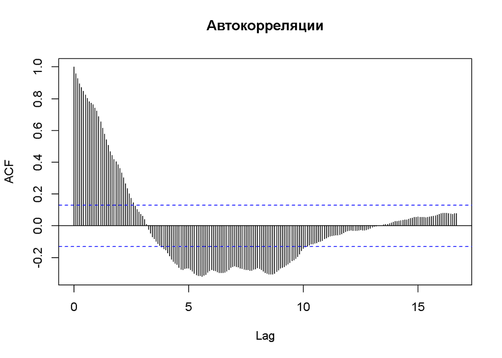

```r
acf(series_ts, lag.max = 200,main="Автокорреляции")
```

Если исходная функция строго периодическая, то на графике автокорреляционной функции тоже будет строго периодическая функция. Но судить о периодичности исходной функции, а следовательно, и о её частотных характеристиках лучше смотреть по периодограмме.

# 3 Периодограмма

Пусть $X_N = (x_1,\ldots,x_N)$ - ряд длины N.
$$x_n=c_0+\sum^{[N/2]}_{k=1}(c_k \cos(2\pi nk/N)+s_k\sin(2\pi nk/N)),$$
Разложение Фурье ряда $X_N$. Здесь $0<=n<N$ и $s_{N/2}=0$ для четного $N$.
Периодограммой ряда $X_N$ называется функция $П^{N}_{x}$, которая задается формулой
$$\begin{equation*}
П^{N}_{x}= \frac{N}{2}
\begin{cases}
2c^2_0 &\text{для $k=0$}\\
c^2_k+s^2_k &\text{для $0<k<N/2$}\\ 2c^2_{N/2} &\text{для $k=N/2$}
\end{cases}
\end{equation*}$$

Норма ряда имеет вид
$$||X_N||^2=\sum^{[N/2]}_{k=0}П^N_x(k/N).$$
Другими словами значение периодограммы в точке k/N описывает вклад гармонической компоненты с частатой $\omega = k/N$. По периодограмме можно понять, какие частоты есть в разложении Фурье данного ряда.
С помощью периодограммы видим из каких частот состоит ряд. Для этого разложим в ряд Фурье (по ортогональному базису состоящему из sin и cos). Смотрим на соответствующие коэффициенты $C_k$ и $S_k$.
Добавляя фазу разложение по базису можно записать в виде косинусов ($A_0=C_0)$):
$$x_n=A_0+ \sum^{[N/2]}_{k=1} A_k \cos (2\pi n \frac{k}{N} +\phi_k)$$
где $A_k$ - амплитуда, $\phi_k$ - фаза. По $A^2_k= C_k^2+ S_k^2$ смотрим вклад частоты в ряд. Частота $\omega = \frac{1}{T}$, то есть по периодограмме видим из каких частот состоит ряд. Минимальные период $T=1$, тогда $w=\frac{1}{2}$.
По сути происходит разложение ряда в сумму косинусов и мы смотрим с какими периодами косинусы входят в сумму (не все косинусы могут входить в сумму).

## 3.1 Общая периодограмма

Видно, что колебания с частотой 1/12 вносят вклад. То есть ряд содержит периодическую компоненту с периодами 12.Аналогично с периодическими компонентами 6 и 2.

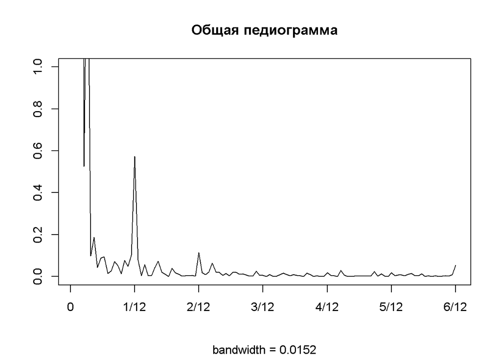

```r
#spec.pgram(series_ts,log="no",detrend = TRUE,taper=0,xaxt='n',ann="False")
#,detrend = TRUE,demean=TRUE
#detrend = false вычитание линейного тренда
#lines(x=rep(1/144,70),y=c(1:70),type="l",col = "red")


spec.pgram(series_ts,ylim=c(0,1),log="no",detrend=FALSE,xaxt='n',fast =FALSE,main="Общая педиограмма",ann="False")
axis(1, at = c(0,1,2,3,4,5,6), labels = c('0', '1/12', '2/12', '3/12', '4/12', '5/12', '6/12'))
```

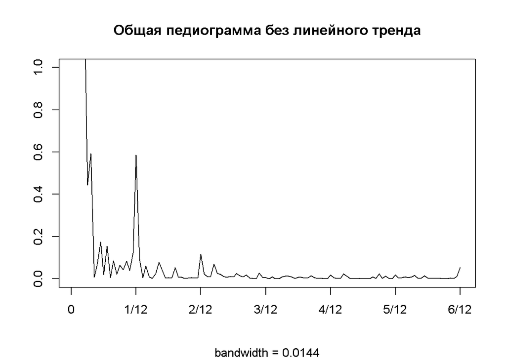

```r
spec.pgram(series_ts,ylim=c(0,1),log="no",detrend=TRUE,xaxt='n',fast =TRUE,main="Общая педиограмма без линейного тренда",ann="False")
axis(1, at = c(0,1,2,3,4,5,6), labels = c('0', '1/12', '2/12', '3/12', '4/12', '5/12', '6/12'))
```

```r
#fast -если TRUE , дополняйте серию до длины, раскладываемаю в произведение небольших сомножителей (в идеале - степень двойки), чтобы быстрее считалось FFT.
#demean -Если TRUE , вычтите среднее значение ряда.
#detrend - Если TRUE , удалите линейный тренд из ряда. Это также удалит среднее. - лучше видим переодичность
```

# 4 Красный и белый шум

## 4.1 Белый шум

Белый шум — стационарный шум, спектральные составляющие которого равномерно распределены по всему диапазону задействованных частот.  
Для сглаживания (выделения спектрально плотности) добавим spans - вектор нечетных целых чисел, дающий ширину модифицированных сглаживателей Даниэля, которые будут использоваться для сглаживания периодограммы.Окно Даниэля означает простое (с равными весами) сглаживание скользящим средним значений периодограммы.  
Периодограмма белого шума (красная линия - оценка спектральной плотности сглаживанием периодограммы):

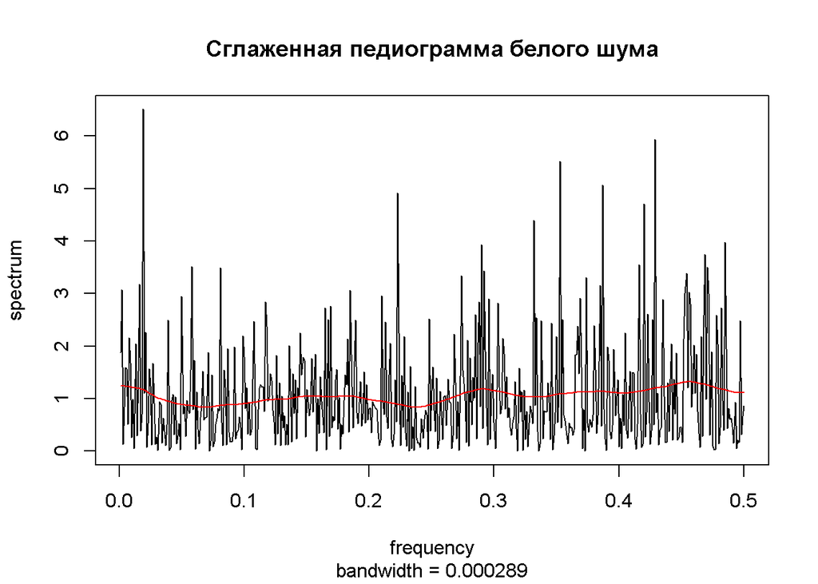

```r
w_noise <- rnorm(1000)

spec.pgram(w_noise, log = "no",fast = FALSE, pad = FALSE,taper = 0,main="Сглаженная педиограмма белого шума")
#Предполагаем, что спектральная плотность медленно меняется от частоты к частоте поэтому беру spans = c(50,50)
spec.pgram(w_noise,spans = c(50,50),detrend = FALSE, log = "no",fast = FALSE, pad = FALSE,taper = 0,xaxt='n', col="red", add=TRUE,xaxt='n')
```

Убедимся по Автокорреляции, что это белый шум:

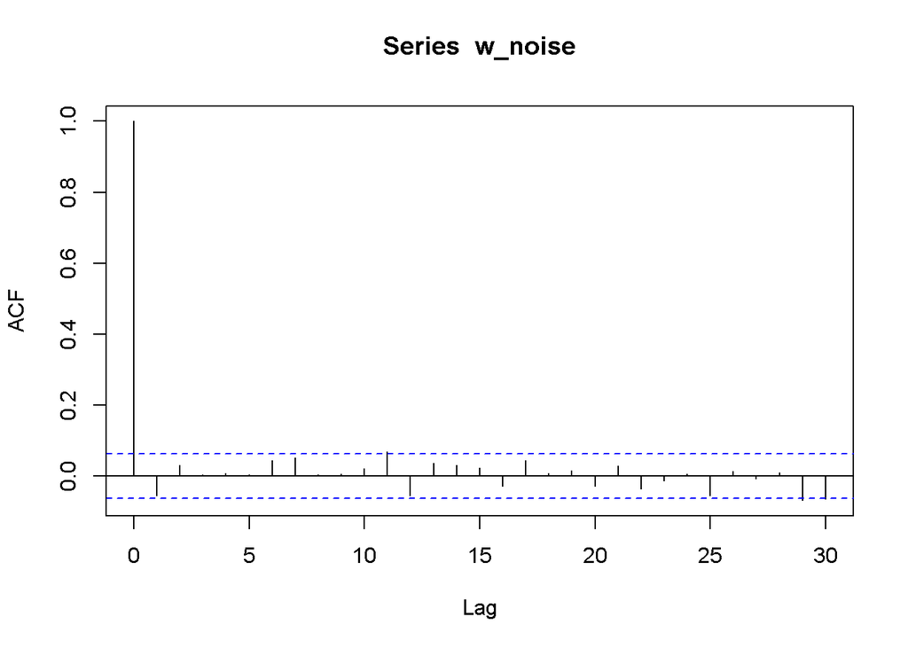

```r
acf(w_noise)
```

## 4.2 Красный шум

У красного шума побольше низких частот и поменьше высоких. Другими словами низкие частоты искажает больше, чем белый, что означает, что при красном шуме Тренд выделить сложнее.  
$\xi_n = a \xi_{n-1} + \epsilon, 0<a<1$ Периодограмма красный шум (Броуновский шум):

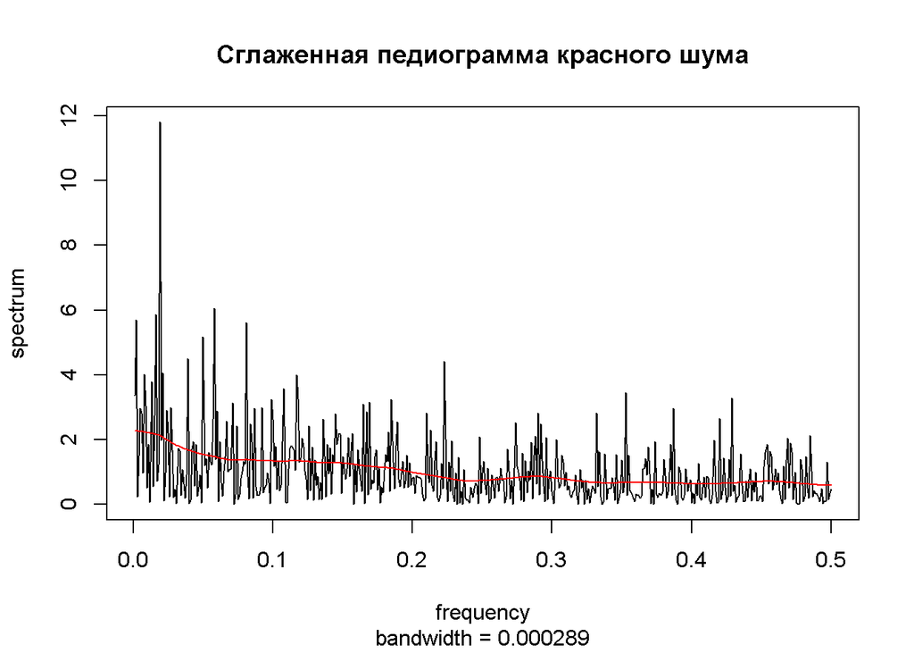

```r
bm <- w_noise[1]
for(i in 1:(1000 - 1)){
 bm[i + 1] <- 0.3*bm[i] + sqrt(1 - 0.1) * w_noise[i+1]
}
bm <- ts(bm)


spec.pgram(bm, log = "no",fast = FALSE, pad = FALSE,taper = 0,main="Сглаженная педиограмма красного шума")

spec.pgram(bm,spans = c(50,50),detrend = FALSE, log = "no",fast = FALSE, pad = FALSE,taper = 0,xaxt='n', col="red", add=TRUE,xaxt='n')
```

Знаем, что у шума
$$\frac{1}{N}||X_N||^2=\sum^N_{k=0}I^N_x(\frac{k}{N}) \rightarrow const, \text{ при } N\rightarrow\infty$$
где $I^N_x(\frac{k}{N})=П^N_x(\frac{k}{N})/N$. Среднее значение с увеличением N уменьшается, так как левая часть не изсеняется, а в правой увеличивается количество слагаемых с ростом N.

# 5 Выделение тренда и подавление шума.

## 5.1 Фильтрация

Фильтрация – способ подавления шума, выделения тренда (тенденцию изменения показателей временного ряда).
Линейный фильтр – линейная комбинация элементов исходного ряда с некоторыми коэффициентами.
$$y_j=\sum^{\infty}_{i=-\infty}h_ix_{j-k}, \text{где $h_i$ параметры фильтра.}$$
$\{h_i\}$ - импульсная характеристика ($\ldots,h_{-1}, h_0,h_1,\ldots$).
КИХ (конечная импульсная характеристика FIR) – конечное число ненулевых $h_j$.
$$y_j=\sum^{r_2}_{i=-r_1}h_ix_{j-k}$$
Частный случай линейного фильтра – скользящее среднее.
Будем использовать встроенную функцию filter, которая при параметре method=”convolution” фильтрует с помощью скользящего среднего.

```r
#Moving Average
filter_MA<-function(x,w)
{
  res<-filter(x,c(1/(2*w), rep(1/w, w-1), 1/(2*w)),method="convolution",sides=2)
  plot(x,type="l")
  lines(res,col="red")
}
filter_MAR<-function(x,w)
{
  res<-filter(x,c(1/(2*w), rep(1/w, w-1), 1/(2*w)),method="convolution",sides=2)
  return(res)
}
```

Воспользуемся фильтром с периодом 12 чтобы убрать сезонность. Посмотрим его АЧХ. Помним, что если период четный, у нас 12, тогда лучше взять длину окна 13 таким образом, чтобы крайние были по половинке частоты.

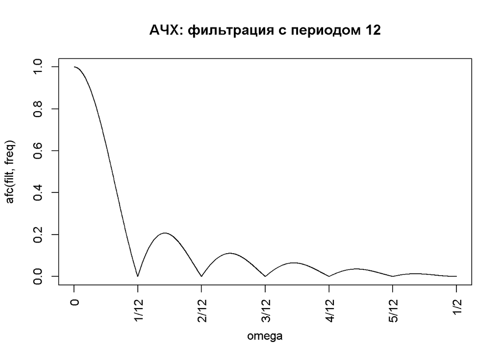

```r
afc <- function(filter, omega) {
  k <- seq_along(filter) - 1
  h <- function(o) sum(rev(filter) * exp(-k*1i * o))
  abs(sapply(omega, h))
}


freq <- seq(0, pi, 0.001)
filt <- c(1/24, rep(1/12, 11), 1/24)
omega <- freq/2/pi
plot(afc(filt, freq) ~ omega, type = "l",xaxt="n",main="АЧХ: фильтрация с периодом 12")
axis(1, at = c( 0,1/12, 2/12, 3/12, 4/12, 5/12,1/2), labels = c("0","1/12", "2/12", "3/12", "4/12", "5/12","1/2"), las = 2)
```

По АЧХ видно что обнуляется частоты с перодом 12,6 и тд и как уменьшает высокие частоты.  
Посмотрим на периодограмму данного фильтра.

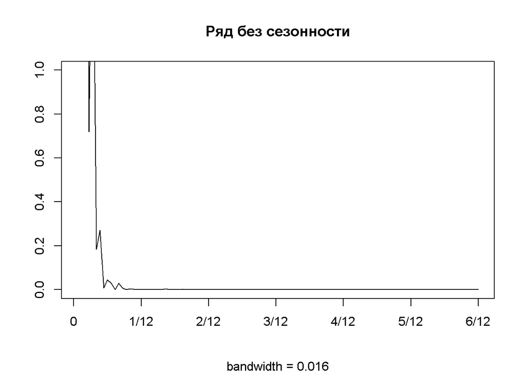

```r
filter_12<-filter(series_ts,filt,method="convolution",sides=2)
#,ylim=c(0,1)
spec.pgram(filter_12,ylim=c(0,1),log="no",detrend=FALSE,xaxt='n',fast =FALSE,main="Ряд без сезонности",ann="False", na.action = na.omit)
axis(1, at = c(0,1,2,3,4,5,6), labels = c('0', '1/12', '2/12', '3/12', '4/12', '5/12', '6/12'))
```

По периодограмме видно, что сезонности нет. Пиков, кроме низких частот, нет, значит фильтр сработал хорошо. Давайте посомтрим как выглядит сам график теперь.

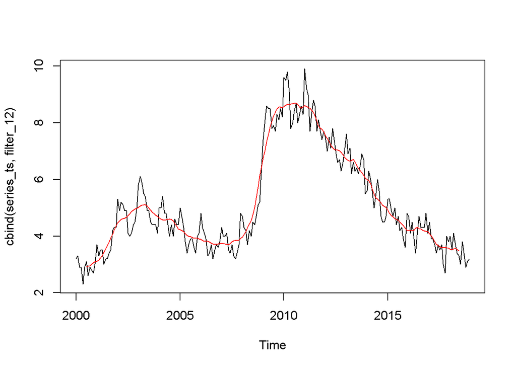

```r
plot.ts(cbind(series_ts,filter_12), plot.type = "single",col=c("black","red"))
```